# Chapter2

### Exercises

2M1. Recall the globe tossing model from the chapter. Compute and plot the grid approximate posterior distribution for each of the following sets of observations. In each case, assume a uniform prior for p. (1) W, W, W (2) W, W, W, L (3) L, W, W, L, W, W, W

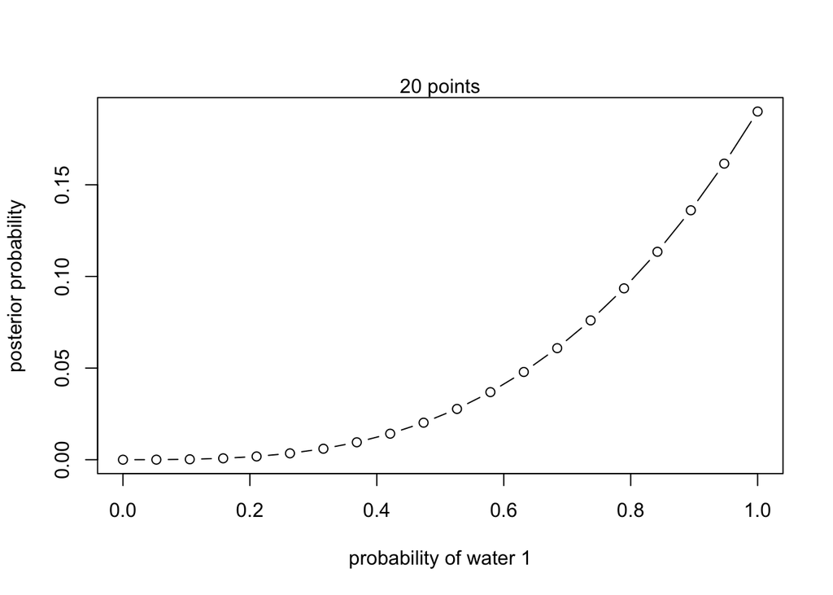

```r
p_grid <- seq( from=0 , to=1 , length.out=20 )
# define prior
prior <- rep( 1 , 20 )# compute likelihood at each value in grid
likelihood <- dbinom( 3, size=3 , prob=p_grid )
# compute product of likelihood and prior
unstd.posterior <- likelihood * prior
# standardize the posterior, so it sums to 1
posterior <- unstd.posterior / sum(unstd.posterior)

plot( p_grid , posterior , type="b" ,
xlab="probability of water 1" , ylab="posterior probability" )
mtext( "20 points" )
```

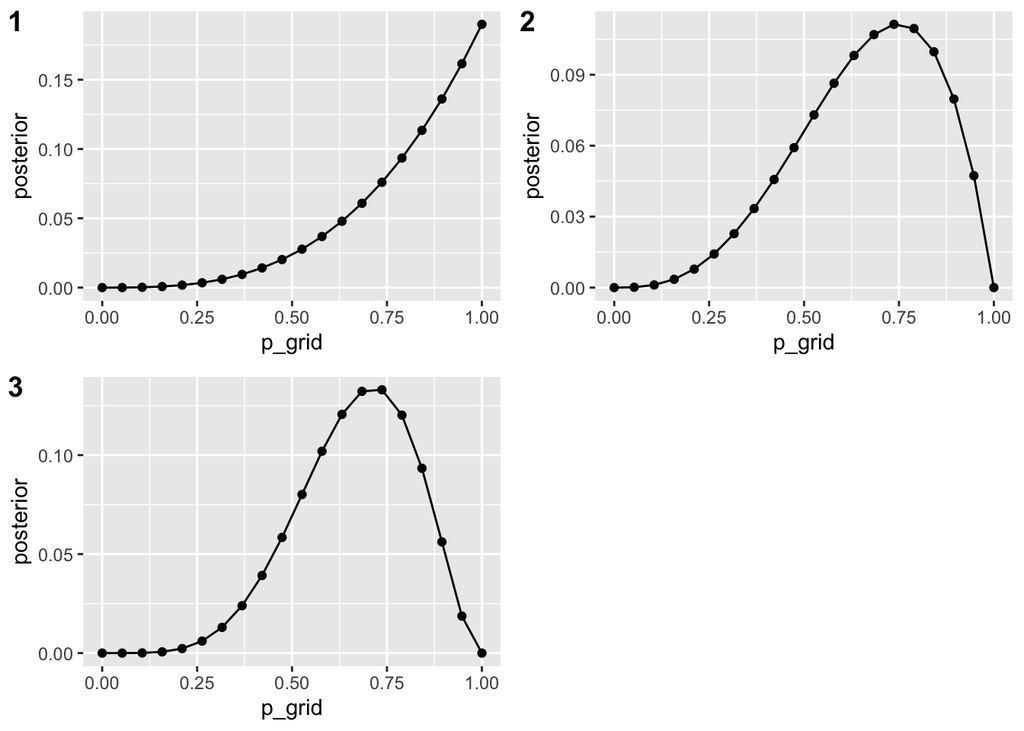

```r
df1<-data.frame(p_grid, posterior)
a<-ggplot(df1,aes(x=p_grid, y=posterior)) + geom_point() +
  geom_line()
#2
likelihood <- dbinom( 3, size=4 , prob=p_grid )
unstd.posterior <- likelihood * prior
posterior <- unstd.posterior / sum(unstd.posterior)
df2<-data.frame(p_grid, posterior)
b<-ggplot(df2,aes(x=p_grid, y=posterior)) + geom_point() +
  geom_line()
#3
likelihood <- dbinom( 5, size=7 , prob=p_grid )
unstd.posterior <- likelihood * prior
posterior <- unstd.posterior / sum(unstd.posterior)
df3<-data.frame(p_grid, posterior)
c<-ggplot(df3,aes(x=p_grid, y=posterior)) + geom_point() +
  geom_line()

plot_grid(a,b,c, labels = c("1","2","3"),ncol = 2)
```

2M2. Now assume a prior for p that is equal to zero when p < 0.5 and is a positive constant when p ≥0.5. Again compute and plot the grid approximate posterior distribution for each of the sets of observations in the problem just above.

```r
p_grid <- seq( from=0 , to=1 , length.out=20 )
prior <- ifelse( p_grid < 0.5 , 0 , 1 )
```

2M3. Suppose there are two globes, one for Earth and one for Mars. The Earth globe is 70% covered in water. The Mars globe is 100% land. Further suppose that one of these globes—you don’t know which—was tossed in the air and produced a “land” observation. Assume that each globe was equally likely to be tossed. Show that the posterior probability that the globe was the Earth, conditional on seeing “land” (Pr(Earth|land)), is 0.23.